# spinifex: Visualizing local structure of high dim data

[figure not shown]

[figure not shown]

Let high dim space be a euclidean space, $\mathbb{R}^p,~~p>3$, where $p$ are numeric variables

Explore how indivudual variables contribute to a feature:

- **Tab 1: spinifex:** examine the contribution of one variable on the structure using manual rotation
- Tab 2: tourr: generally view random or guided sequences of projections of high-dimensional data
- Tab 3: comparison: PCA, t-SNE, tour
- Tab 4: contact: how to find the code and get more details
- Tab 5: more: additional tourr package enhancements

[figure not shown]

View at 150% zoom from Firefox or Chrome

### spinifex

#### Data - flea

74 obs x 6 var of physical measurements taken across 3 different species of flea-beetles. Methods are unsupervized, but data are colored according to species.

### tourr

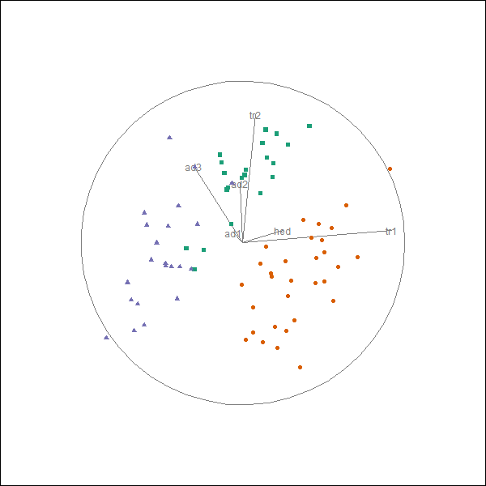

### comparison

- Principal component analysis (PCA): $p$ ordered linear combinations of $p$ dimensions. Plot PC1 vs PC2
- t-distributed Stochastic Neighbor Embedding (t-SNE): $p$ unordered non-linear combinations of $p$ dimensions. Do PCA and Plot PC1 vs PC2
- Tour (Holes optimized): stochastic gradient opmitization of white space in the middle of projections (from $p$ down to 2 dimensions)

[output not shown]

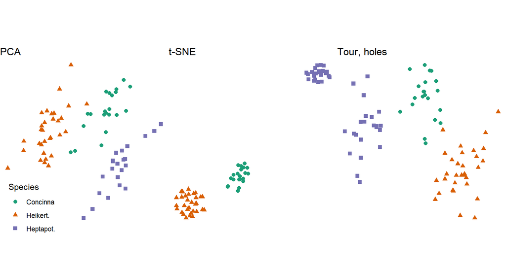

```r
f.pca <- stats::prcomp(flea)
ggplot2::ggplot(f.pca) + ...

f.tsne <- Rtsne(f, ...)
f.tsne.pca <- stats::prcomp(f.tsne)
ggplot2::ggplot(f.tsne.pca) + ...

f.holes_end <- tourr::animate_xy(flea, guided_tour(index = holes))
ggplot2::ggplot(f.holes_end) + ...
```

#### Variation lost from dimension reduction

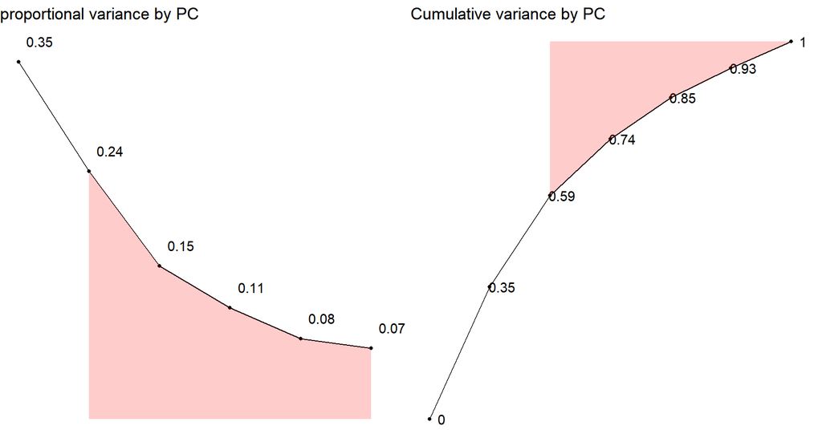

### contact

**Nick S Spyrison**  
nicholas.spyrison@monash.edu  
github.com/nspyrison [scholar.google.com.au/](https://scholar.google.com.au/citations?user=zzM9WVEAAAAJ&hl=en)

#### Install

```r
devtools::install_github("nspyrison/spinifex")
library(spinifex)

vignette("spinifex")
```

#### Thanks

- Prof. Dianne Cook - Guidance, namesake, and contributions to projection pursuit
- Dr. Ursula Laa - Collaboration, use cases, and dev feedback

#### References

1. H. Wickham, D. Cook, H. Hofmann, and A. Buja (2011). tourr: An r package for exploring multivariate data with projections. Journal of Statistical Software 40(2), http://www.jstatsoft.org/v40.
2. D. Asimov (1985). The grand tour: a tool for viewing multidimensional data. SIAM Journal on Scientific and Statistical Computing, 6(1), 128–143.
3. D. Cook, & A. Buja (1997). Manual Controls for High-Dimensional Data Projections. Journal of Computational and Graphical Statistics, 6(4), 464–480. https://doi.org/10.2307/1390747
4. H. Wickham, D. Cook, and H. Hofmann (2015). Visualising statistical models: Removing the blindfold (withdiscussion). Statistical Analysis and Data Mining 8(4), 203–225.

#### Other reading

- [Namesake: spinifex hopping mouse](https://en.wikipedia.org/wiki/Spinifex_hopping_mouse)
  - To quote Di: “it spins, it hops and needs a ‘mouse’”
- [Principal component analysis](https://en.wikipedia.org/wiki/Principal_component_analysis)
- [t-distributed stochastic neighbor embedding](https://en.wikipedia.org/wiki/T-distributed_stochastic_neighbor_embedding)
- [Projection pursuit](https://en.wikipedia.org/wiki/Projection_pursuit)
- [Stochastic gradient optimization](https://en.wikipedia.org/wiki/Stochastic_gradient_descent)
- Grand tour

### more

```r
devtools::install_github("nspyrison/tourr")
library(tourr)

?tourr::animate_groupxy()
?tourr::animate_density2d()
```

#### animate_groupxy()

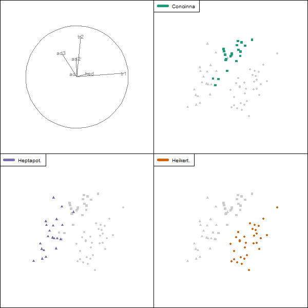

#### animate_density2d()

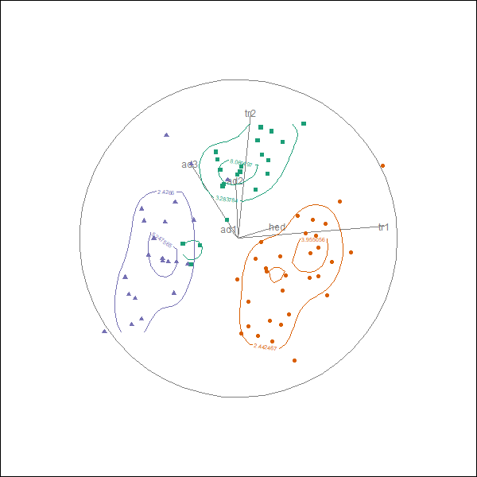